# Zoning with GeoFIS

Package GeoFIS 1.0.2

Jean-Luc Lablée, Serge Guillaume

## Introduction

This vignette shows how to generate management zones from data with GeoFIS (Pedroso et al. 2010).

See [Zoning documentation](https://www.geofis.org/en/documentation-en/zoning/) for more details about the zoning algorithm.

```r
library(GeoFIS)
```

## Loading data

The zoning process accepts input dataset of class `SpatialPointsDataFrame` or `SpatialMultiPointsDataFrame` of the sp R package.  
It keeps only the attributes that can be used in the zoning process, meaning numeric attributes, without missing values and with a range that is not limited to a unique value. The last condition is required by the min-max standardization process.  
The input dataset must be in a projected coordinate reference system.

In this example the `conductivity_2014` input dataset is used. It is included in the GeoFIS R package, each location is described by a single numeric attribute `conduct`:

```r
data(conductivity_2014)
zoning <- NewZoning(conductivity_2014)
```

The zonable dataset used by the zoning process is available through the `zonable_data` method. In this example `zonable_data` is identical to `conductivity_2014`.

```r
zonable_data <- zoning$zonable_data()
```

## Main parameters

### The border

The border is a polygon used to limit the processed area. Only data points within the border are processed.

If `NULL` the Convex Hull polygon of the input dataset will be used (computed with gConvexHull function of the rgeos R package).

```r
zoning$border <- NULL
```

An object of class SpatialPolygons can be used as border:

```r
data(conductivity_border)
zoning$border <- conductivity_border
```

#### Show the Voronoi diagram

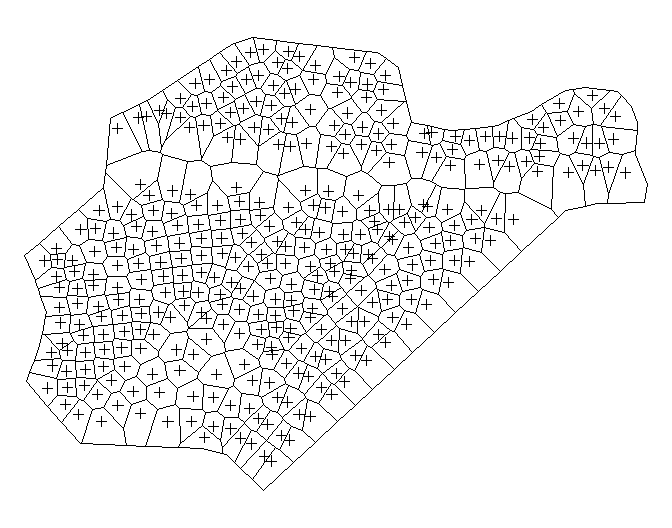

```r
zoning$perform_voronoi()
vm <- zoning$voronoi_map()
par(mar = c(0, 0, 0, 0))
plot(vm)
plot(zoning$zonable_data(), add = TRUE)
```

### The neighborhood

The neighborhood relation can be filtered by a minimal common edge length.

If `NULL` all contiguous Voronoi polygons are considered as neighbors:

```r
zoning$neighborhood <- NULL
```

The user can define the minimum edge length (in the same unit as the input dataset coordinate system) shared by two Voronoi polygons for being considered as neighbors:

```r
zoning$neighborhood <- 5
```

#### Show the neighborhood relations

The red lines shows the pairs of Voronoi polygons that are no longer considered as neighbors.

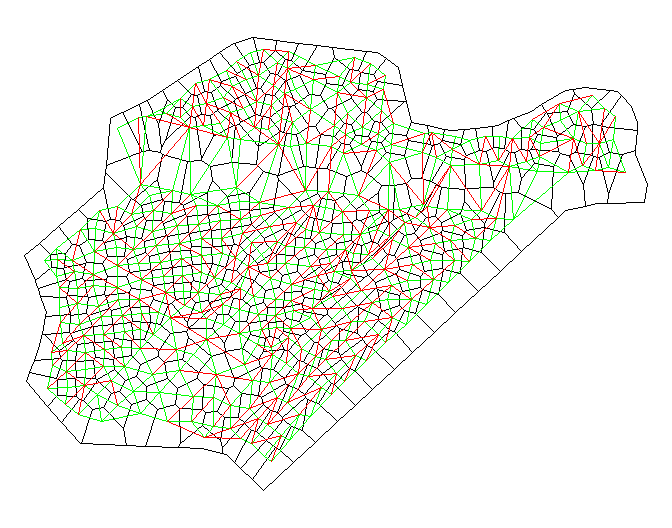

```r
zoning$perform_neighborhood()
nm <- zoning$neighborhood_map()
par(mar = c(0, 0, 0, 0))
plot(vm)
plot(subset(nm, filtered == FALSE), add = TRUE, col = "green")
plot(subset(nm, filtered == TRUE), add = TRUE, col = "red")
```

### Attribute distance

This distance function is used for a given attribute. It computes the distance between two data points in the monodimensional attribute space. As many distance functions as there are attributes in the zonable dataset are needed (in a list if multiple attributes).  
Two univariate distances are available: `EuclideanDistance` (the default) or `FuzzyDistance`. Or `NULL` if the attribute should not be used in the zoning process.

The fuzzy distance function is based on a fuzzy partition that allows for integrating expert knowledge into distance calculations (Guillaume, Charnomordic, and Loisel 2013; Guillaume and Charnomordic 2013). The partition must be a standardized fuzzy partition based on a `FisIn` object of the FisPro R package.

The following command-line sets the fuzzy distance based on 3 Mfs-partition defined by the following breakpoints: 20, 30, 100. The range of the `conduct` attribute is [12, 116]:

```r
zoning$attribute_distance <- FuzzyDistance(NewFisIn(c(20, 30, 100), 12, 116))
```

The default value, used in this example, is the euclidean distance:

```r
zoning$attribute_distance <- EuclideanDistance()
```

### Zone distance aggregation

To compute the distance between two zones, all the data points included in the two zones are considered and the aggregation is done using the aggreg parameter:

$$d(z_i,z_j) = (Aggreg) d(x,y), \forall x \in z_i, y \in z_j$$
Three aggreg operators are available: `MinimumDistance`, `MaximumDistance` (the default) or `MeanDistance`.
The two zones to be merged at a given iteration are the ones for which the zone distance is minimum.

```r
zoning$zone_distance <- MaximumDistance()
```

### Combine distance

The combination function distance is needed when the zoning is done according to several attributes. In this case, each univariate or elementary distance is computed and normalized in a unit interval. These partial distances are then aggregated to yield the distance between two data points in the multidimensional attribute space. The distance combination is done before computing the between-zones distance.  
Two combinations are proposed: `EuclideanDistance` (the default) or `MinkowskiDistance`.

```r
zoning$combine_distance <- EuclideanDistance()
```

### Smallest zone

This criterion is used to determine the smallest size for a zone (number of points or area) to be kept in the final map. The zones with a size less than the threshold are included in the most compatible neighboring zone.  
The two available parameters are: `ZoneSize` or `ZoneArea`.  
The default value is `ZoneSize` with 1 point.

```r
zoning$smallest_zone <- ZoneSize(1)
```

## Perform zoning

```r
zoning$perform_zoning()
```

Get the map with 5 zones:

```r
map5 <- zoning$map(5)
```

The result map contains for each zone:

- the id
- the number of points
- the area
- the mean of the attribute
- the std of the attribute

```r
print(map5@data)
```

```
#>    id size      area conduct_mean conduct_std
#> 1 282   13  1691.965     93.15385   11.700402
#> 2 101   31  2442.451     87.29032    9.395241
#> 3   1  107 13123.461     36.40187   11.362226
#> 4  10  175 21098.067     60.05714   11.161011
#> 5 106   27  2683.125     41.77778   10.897955
```

Plot the map:

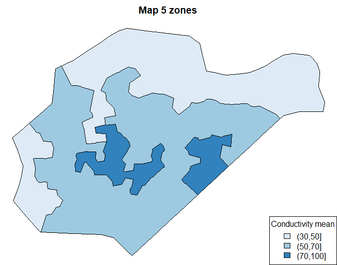

```r
library(RColorBrewer)

palette <- brewer.pal(3, "Blues")
breaks <- c(30, 50, 70, 100)
colors <- palette[findInterval(map5$conduct_mean, vec = breaks)]
par(mar = c(0, 0, 2, 0))
plot(map5, col = colors, main = "Map 5 zones")
legend("bottomright", legend = levels(cut(map5$conduct_mean, breaks)),
  fill = palette, title = "Conductivity mean")
```

### Save the map

Any map can be exported to various common file format, e.g. Shapefile (rgdal package is required): replace tempdir() with the directory you want to export the map

```r
if (require(rgdal))
  writeOGR(map5, dsn = tempdir(), layer = "map5", driver = "ESRI Shapefile")
```

## Publications

Guillaume, Serge, and Brigitte Charnomordic. 2013. “Fuzzy Partition-Based Distance Practical Use and Implementation.” In *IEEE International Conference on Fuzzy Systems, Paper f-1136*, edited by IEEE Catalog Number: CFP12FUZ-USB. Hyderabad, India: IEEE.

Guillaume, Serge, Brigitte Charnomordic, and Patrice Loisel. 2013. “Fuzzy Partitions: A Way to Integrate Expert Knowledge into Distance Calculations.” *International Journal of Information Sciences* 245: 76–95. https://doi.org/10.1016/j.ins.2012.07.045.

Leroux, Corentin, Hazaël Jones, Léo Pichon, Serge Guillaume, Julien Lamour, James Taylor, Olivier Naud, Thomas Crestey, Jean-Luc Lablee, and Bruno Tisseyre. 2018. “GeoFIS: An Open Source, Decision-Support Tool for Precision Agriculture Data.” *Agriculture* 8 (6). https://doi.org/10.3390/agriculture8060073.

Pedroso, Moacir, James Taylor, Bruno Tisseyre, Brigitte Charnomordic, and Serge Guillaume. 2010. “A Segmentation Algorithm for the Delineation of Management Zones.” *Computer and Electronics in Agriculture* 70 (1): 199–208. https://doi.org/10.1016/j.compag.2009.10.007.